# Arabidopsis Case Study

2025-02-25

## About

This tutorial demonstrates the R package [`cpam`](https://github.com/l-a-yates/cpam) for the analysis of time series omics data. It serves an introduction to the package and reproduces the results for the second case study presented in the accompanying [manuscript](https://doi.org/10.1101/2024.12.22.630003) by Yates et al. (2024). A tutorial for first case study using human embryo time series data is available [here](https://raw.githack.com/l-a-yates/cpam_manuscript/main/R/torre.html).

## Data

The transcript-to-gene mapping for Arabidopsis thaliana can be downloaded from The Arabidopsis Information Resource (TAIR) (https://www.arabidopsis.org/).

## Installation

You can install [`cpam`](https://github.com/l-a-yates/cpam) from GitHub using:

```r
devtools::install_github("l-a-yates/cpam")
```

# Getting started

## Load packages

```r
library(cpam)
library(dplyr)
library(readr)
library(tidyr)
library(stringr)
library(ggplot2)
```

## Experimental design and transcript-to-gene mapping

First we create the experimental design tibble which must have at least the following columns: time, sample, and path. The `rep` column is optional and is used here to generate the sample names. We used the software [kallisto](https://doi.org/10.1038/nbt.3519) to quantify counts from the RNA-seq data (with 100 bootstrap replicates). The `path` column contains the path to the kallisto abundance file for each sample.

```r
ed <-
  expand_grid(time = c(0,30,60,67.5,75,90,120), rep = 1:3) %>%
  mutate(sample = paste0("pc_t",time,"_r",rep),
         path = paste0("case_studies/crisp/data/kallisto/",sample,"/abundance.h5"))

ed
```

| time | rep | sample | path |
| --- | --- | --- | --- |
| 0.0 | 1 | pc_t0_r1 | case_studies/crisp/data/kallisto/pc_t0_r1/abundance.h5 |
| 0.0 | 2 | pc_t0_r2 | case_studies/crisp/data/kallisto/pc_t0_r2/abundance.h5 |
| 0.0 | 3 | pc_t0_r3 | case_studies/crisp/data/kallisto/pc_t0_r3/abundance.h5 |
| 30.0 | 1 | pc_t30_r1 | case_studies/crisp/data/kallisto/pc_t30_r1/abundance.h5 |
| 30.0 | 2 | pc_t30_r2 | case_studies/crisp/data/kallisto/pc_t30_r2/abundance.h5 |
| 30.0 | 3 | pc_t30_r3 | case_studies/crisp/data/kallisto/pc_t30_r3/abundance.h5 |
| 60.0 | 1 | pc_t60_r1 | case_studies/crisp/data/kallisto/pc_t60_r1/abundance.h5 |
| 60.0 | 2 | pc_t60_r2 | case_studies/crisp/data/kallisto/pc_t60_r2/abundance.h5 |
| 60.0 | 3 | pc_t60_r3 | case_studies/crisp/data/kallisto/pc_t60_r3/abundance.h5 |
| 67.5 | 1 | pc_t67.5_r1 | case_studies/crisp/data/kallisto/pc_t67.5_r1/abundance.h5 |

[output cut: 11 more lines]

We have already downloaded (https://www.arabidopsis.org/) the transcript-to-gene mapping for Arabidopsis thaliana and we load it now.

```r
t2g <- readr::read_csv("t2g.csv")
```

This file should have two columns, target_id and gene_id.

```r
head(t2g)
```

| target_id | gene_id |
| --- | --- |
| AT1G01010.1 | AT1G01010 |
| AT1G01020.2 | AT1G01020 |
| AT1G01020.6 | AT1G01020 |
| AT1G01020.1 | AT1G01020 |
| AT1G01020.4 | AT1G01020 |
| AT1G01020.5 | AT1G01020 |

## Fitting the models

To fit the models, we first prepare the `cpam` object, then compute p-values, estimate the changepoints, and select the shape for each transcript. The last step takes the longest (here just under 13 minutes) but it is worth the wait to be able to visualise and cluster the transcripts by shape.

```r
  cpo <- prepare_cpam(exp_design = ed,
                      model_type = "case-only",
                      t2g = t2g,
                      import_type = "kallisto",
                      num_cores = 4)
  cpo <- compute_p_values(cpo) # 1:52
  cpo <- estimate_changepoint(cpo) # 6:32 secs
  cpo <- select_shape(cpo) # 12:54 secs
```

We can look at a summary of the fitted cpam object

```r
cpo
## cpam object
## -----------
## case-only time series
## 21 samples
## 7 time points
## Overdispersion estimated using 100 inferential replicates
## Counts rescaled by estimated overdispersion
```

If you run the code on your own computer, you can launch the Shiny app on your own computer to visualise the results interactively using `visualise(cpo)`.

## Result tables

The results of the analysis are summarised using the `results` function.

```r
results(cpo)
```

| target_id | gene_id | p | cp | shape | lfc.0 | lfc.30 | lfc.60 | lfc.67.5 | lfc.75 | lfc.90 | lfc.120 | counts.0 | counts.30 | counts.60 | counts.67.5 | counts.75 | counts.90 | counts.120 |
| --- | --- | --- | --- | --- | --- | --- | --- | --- | --- | --- | --- | --- | --- | --- | --- | --- | --- | --- |
| AT1G02090.1 | AT1G02090 | 0.000000e+00 | 0.0 | tp | 0 | 1.52577259 | 1.0761441858 | 8.181849e-01 | 5.497842e-01 | 2.155948e-01 | 1.832878e-01 | 2.075051e+02 | 5.974921e+02 | 4.375025e+02 | 3.658702e+02 | 3.037598e+02 | 2.409513e+02 | 2.356156e+02 |
| AT1G02090.2 | AT1G02090 | 0.000000e+00 | 0.0 | cv | 0 | 1.21768813 | 0.4531218743 | 2.616459e-01 | 7.014748e-02 | -3.128943e-01 | -1.079103e+00 | 6.997967e+01 | 1.627543e+02 | 9.580214e+01 | 8.389482e+01 | 7.346634e+01 | 5.633540e+01 | 3.312298e+01 |
| AT1G02090.3 | AT1G02090 | 0.000000e+00 | 0.0 | cv | 0 | 2.60575515 | 2.1850770401 | 1.982873e+00 | 1.763303e+00 | 1.282692e+00 | 1.804891e-01 | 2.922902e+01 | 1.779200e+02 | 1.329193e+02 | 1.155363e+02 | 9.922510e+01 | 7.111204e+01 | 3.312432e+01 |
| AT1G04080.1 | AT1G04080 | 0.000000e+00 | 0.0 | tp | 0 | 0.72812462 | 0.7784181291 | 6.688835e-01 | 4.984018e-01 | 1.153523e-01 | -3.835877e-01 | 5.348761e+02 | 8.860140e+02 | 9.174458e+02 | 8.503686e+02 | 7.555916e+02 | 5.793990e+02 | 4.099981e+02 |
| AT1G04080.3 | AT1G04080 | 0.000000e+00 | 0.0 | tp | 0 | -0.55448630 | -0.5488712221 | -4.249927e-01 | -2.610025e-01 | 1.222037e-01 | 6.854476e-01 | 2.043767e+02 | 1.391600e+02 | 1.397027e+02 | 1.522285e+02 | 1.705540e+02 | 2.224429e+02 | 3.286789e+02 |
| AT1G04130.1 | AT1G04130 | 0.000000e+00 | 0.0 | cv | 0 | 3.10047178 | 2.3893963603 | 2.069436e+00 | 1.737702e+00 | 1.059690e+00 | -3.205579e-01 | 7.384210e+01 | 6.333431e+02 | 3.868869e+02 | 3.099319e+02 | 2.462659e+02 | 1.539227e+02 | 5.912982e+01 |
| AT1G04130.2 | AT1G04130 | 0.000000e+00 | 0.0 | cv | 0 | 3.67379902 | 3.1761709340 | 2.907043e+00 | 2.613980e+00 | 1.977344e+00 | 5.676968e-01 | 1.211849e+01 | 1.546579e+02 | 1.095396e+02 | 9.089823e+01 | 7.418817e+01 | 4.771864e+01 | 1.796148e+01 |
| AT1G05870.10 | AT1G05870 | 0.000000e+00 | 60.0 | dlin | 0 | 0.00000000 | 0.0000000000 | -5.545197e-01 | -1.109039e+00 | -2.218079e+00 | -4.436157e+00 | 9.962552e+01 | 9.962552e+01 | 9.962552e+01 | 6.783339e+01 | 4.618665e+01 | 2.141225e+01 | 4.602080e+00 |
| AT1G05870.3 | AT1G05870 | 0.000000e+00 | 0.0 | cv | 0 | 0.72261610 | 0.0578358335 | -1.482403e-01 | -3.593374e-01 | -7.911846e-01 | -1.680150e+00 | 1.012916e+02 | 1.671485e+02 | 1.054347e+02 | 9.140050e+01 | 7.895907e+01 | 5.853331e+01 | 3.160806e+01 |
| AT1G06570.1 | AT1G06570 | 0.000000e+00 | 0.0 | tp | 0 | 1.07839508 | 1.0201224179 | 8.148630e-01 | 5.433166e-01 | 2.214861e-02 | -5.878342e-01 | 3.920278e+02 | 8.278395e+02 | 7.950681e+02 | 6.896284e+02 | 5.713096e+02 | 3.980928e+02 | 2.608322e+02 |

[output cut: 9990 more lines]

```r
results(cpo, min_count = 10, min_lfc = 1, p_threshold = 0.01)
```

| target_id | gene_id | p | cp | shape | lfc.0 | lfc.30 | lfc.60 | lfc.67.5 | lfc.75 | lfc.90 | lfc.120 | counts.0 | counts.30 | counts.60 | counts.67.5 | counts.75 | counts.90 | counts.120 |
| --- | --- | --- | --- | --- | --- | --- | --- | --- | --- | --- | --- | --- | --- | --- | --- | --- | --- | --- |
| AT1G02090.1 | AT1G02090 | 0.000000e+00 | 0.0 | tp | 0 | 1.5257726 | 1.076144186 | 0.818184879 | 5.497842e-01 | 2.155948e-01 | 1.832878e-01 | 2.075051e+02 | 5.974921e+02 | 4.375025e+02 | 3.658702e+02 | 3.037598e+02 | 2.409513e+02 | 2.356156e+02 |
| AT1G02090.2 | AT1G02090 | 0.000000e+00 | 0.0 | cv | 0 | 1.2176881 | 0.453121874 | 0.261645860 | 7.014748e-02 | -3.128943e-01 | -1.079103e+00 | 6.997967e+01 | 1.627543e+02 | 9.580214e+01 | 8.389482e+01 | 7.346634e+01 | 5.633540e+01 | 3.312298e+01 |
| AT1G02090.3 | AT1G02090 | 0.000000e+00 | 0.0 | cv | 0 | 2.6057552 | 2.185077040 | 1.982872582 | 1.763303e+00 | 1.282692e+00 | 1.804891e-01 | 2.922902e+01 | 1.779200e+02 | 1.329193e+02 | 1.155363e+02 | 9.922510e+01 | 7.111204e+01 | 3.312432e+01 |
| AT1G04130.1 | AT1G04130 | 0.000000e+00 | 0.0 | cv | 0 | 3.1004718 | 2.389396360 | 2.069435888 | 1.737702e+00 | 1.059690e+00 | -3.205579e-01 | 7.384210e+01 | 6.333431e+02 | 3.868869e+02 | 3.099319e+02 | 2.462659e+02 | 1.539227e+02 | 5.912982e+01 |
| AT1G04130.2 | AT1G04130 | 0.000000e+00 | 0.0 | cv | 0 | 3.6737990 | 3.176170934 | 2.907042628 | 2.613980e+00 | 1.977344e+00 | 5.676968e-01 | 1.211849e+01 | 1.546579e+02 | 1.095396e+02 | 9.089823e+01 | 7.418817e+01 | 4.771864e+01 | 1.796148e+01 |
| AT1G06570.1 | AT1G06570 | 0.000000e+00 | 0.0 | tp | 0 | 1.0783951 | 1.020122418 | 0.814863034 | 5.433166e-01 | 2.214861e-02 | -5.878342e-01 | 3.920278e+02 | 8.278395e+02 | 7.950681e+02 | 6.896284e+02 | 5.713096e+02 | 3.980928e+02 | 2.608322e+02 |
| AT1G06570.2 | AT1G06570 | 0.000000e+00 | 0.0 | tp | 0 | 1.1243339 | 1.055213417 | 0.779004725 | 4.480006e-01 | -7.326301e-02 | -5.285278e-01 | 1.954775e+02 | 4.261427e+02 | 4.062073e+02 | 3.354290e+02 | 2.666603e+02 | 1.857986e+02 | 1.355171e+02 |
| AT1G07350.1 | AT1G07350 | 0.000000e+00 | 0.0 | tp | 0 | 7.3227555 | 4.966101214 | 3.954200820 | 3.071488e+00 | 1.954096e+00 | 6.260020e-01 | 5.188172e+01 | 8.305837e+03 | 1.621660e+03 | 8.041691e+02 | 4.361384e+02 | 2.010277e+02 | 8.006814e+01 |
| AT1G07350.2 | AT1G07350 | 0.000000e+00 | 0.0 | tp | 0 | 2.4318046 | 2.573944197 | 2.416277081 | 1.746362e+00 | -2.963553e-01 | -2.961914e+00 | 1.930584e+02 | 1.041681e+03 | 1.149537e+03 | 1.030530e+03 | 6.477329e+02 | 1.572088e+02 | 2.477785e+01 |
| AT1G07350.3 | AT1G07350 | 0.000000e+00 | 0.0 | cv | 0 | 3.4238877 | 2.204837348 | 1.208904738 | 1.665647e-01 | -1.958695e+00 | -6.264969e+00 | 4.003444e+01 | 4.296617e+02 | 1.845678e+02 | 9.254445e+01 | 4.493397e+01 | 1.029930e+01 | 5.205834e-01 |

[output cut: 2998 more lines]

## Plotting genes and transcripts

A single gene can be plotted using the `plot_cpam` function. Here we plot the gene AT1G64140

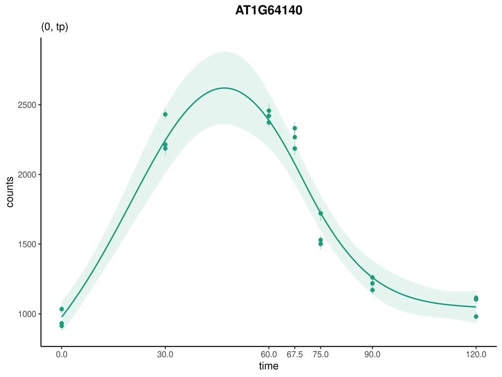

```r
plot_cpam(cpo, gene_id = "AT1G64140")
```

The subtitle shows `(0,tp)` indicating a changepoint at time point 0 (i.e., no changepoint) and an unconstrained `'tp'` (thinplate) shape. This selection of ‘tp’ suggests that the trend for this gene does not conform to one of the simpler shape types that `cpam` uses. To force the `cpam` to choose among the simpler forms, we set `shape_type = "shape2"` in the `plot_cpam` function. For example:

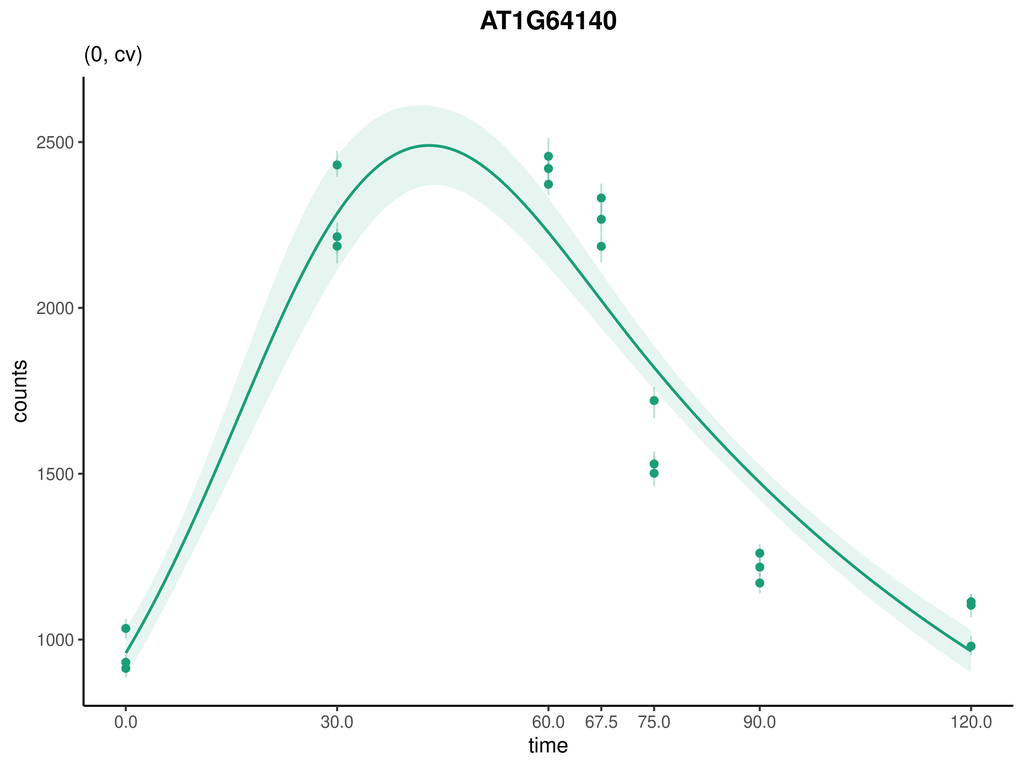

```r
plot_cpam(cpo, gene_id = "AT1G64140",shape_type = "shape2")
```

Here a concave shape (`'cv'`) is chosen, and we can see this trend deviates from the data substantially more that the unconstrained shape. See the manuscript for more details on the shape types available in `cpam`.

Next we plot a gene with multiple transcripts.

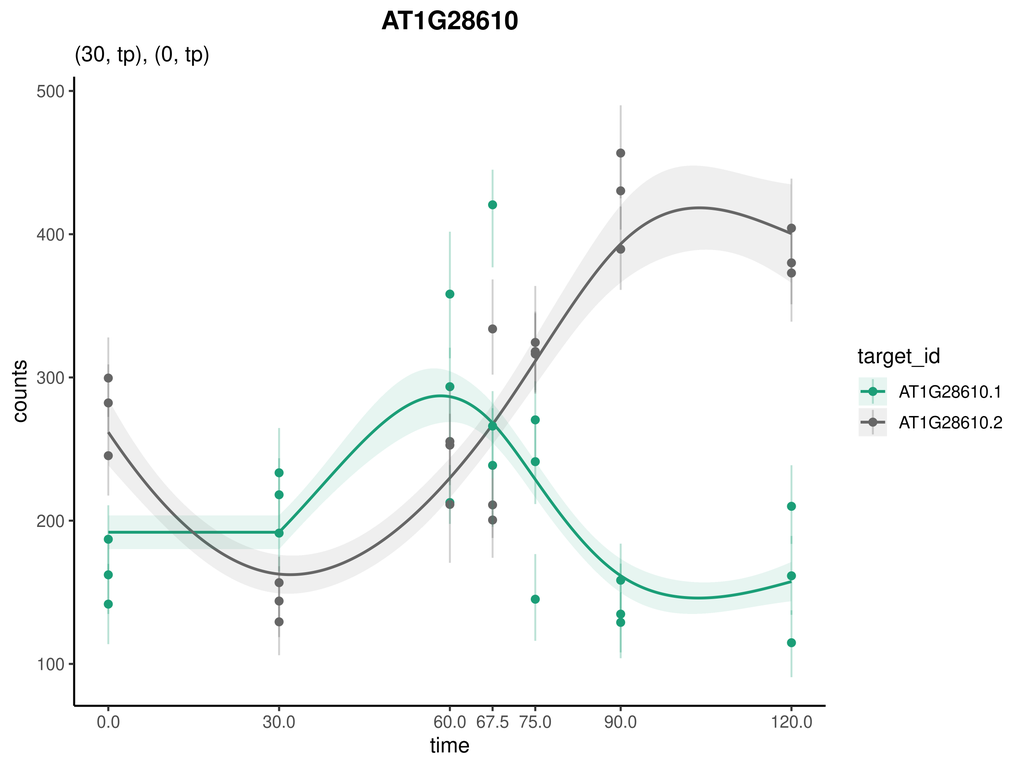

```r
plot_cpam(cpo, gene_id = "AT1G28610")
```

The first transcript has a changepoint at 30 mins and the second at 0. Both have an unconstrained shape. The transcripts can plotted separately by setting `facet = T` in the `plot_cpam` function. There are may other settings that can be adjusted in the `plot_cpam` function, see the documentation for more details. Changepoints, shapes and other results from the fitted models can also be extracted manually from the `cpam` object. For example, to extract the shape of the transcripts

```r
cpo$shapes %>% filter(str_starts(target_id,"AT1G28610"))
```

| target_id | cp | shape1 | shape2 |
| --- | --- | --- | --- |
| AT1G28610.1 | 30 | tp | cv |
| AT1G28610.2 | 0 | tp | micv |

Lastly, we plot the two remaining genes featured in the manuscript, AT4G34590 and AT3G23280.

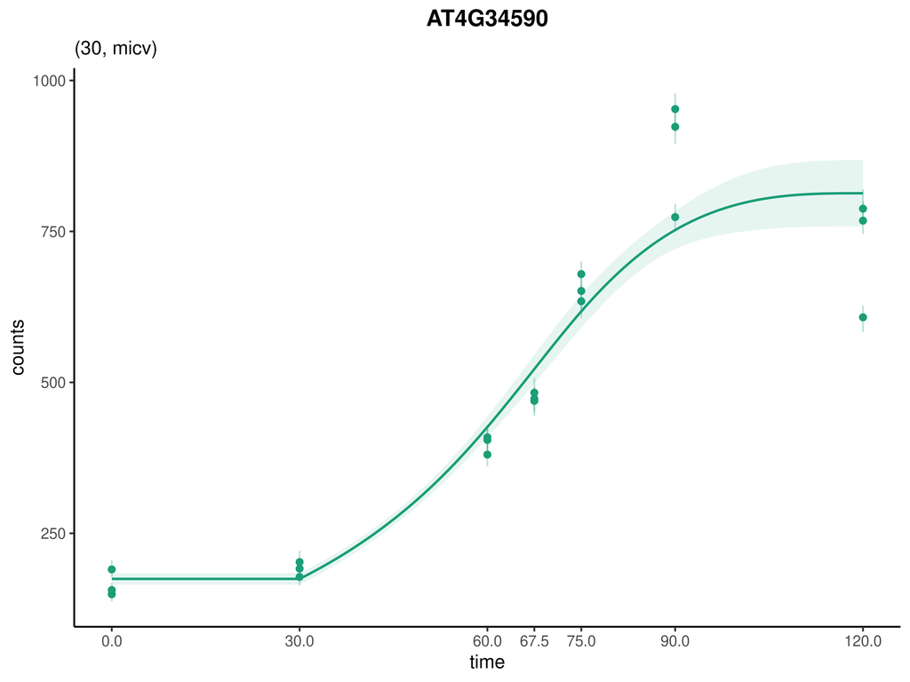

```r
plot_cpam(cpo, gene_id = "AT4G34590")
```

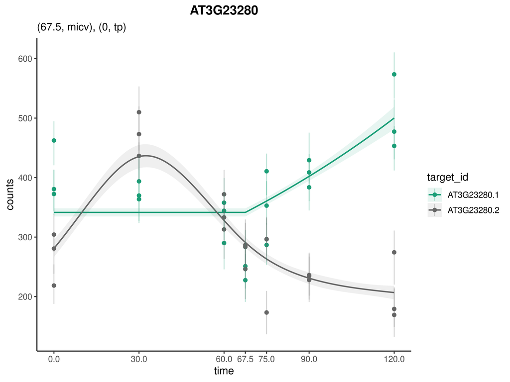

```r
plot_cpam(cpo, gene_id = "AT3G23280")
```

## Clusters

The results function can be used to generate clusters according to selected filters. Here we generate clusters of transcripts with at least 100 counts, a log-fold change greater than 1, and a p-value less than 0.01. The `plot_cluster` function can then be used to visualise the clusters which we do here for targets with changepoints at 30 mins and the ‘micv’ (montonic increasing concave) shape.

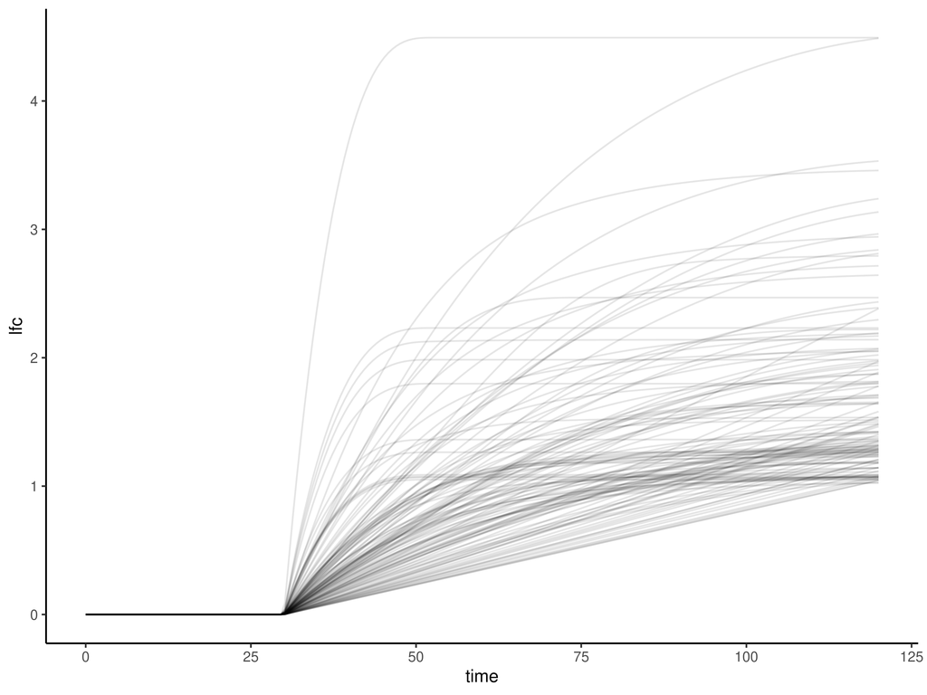

```r
res <- results(cpo, min_count = 100, min_lfc = 1, p_threshold = 0.01)
plot_cluster(cpo, res, changepoints = 30, shapes = "micv")
```

Clustering can be further refined based on, for example, the rate at which the above transcripts attain their maximum values. We illustrate advanced refinements such as this in our other case study [here](https://raw.githack.com/l-a-yates/cpam_manuscript/main/R/torre.html).

## Advanced plotting

### Isoform structure plots

Here we show how to reproduce the isoform structure plots for the gene AT3G23280.

First, download the the gtf file for Arabidopsis thaliana from Ensembl Plants. Using the `rtracklayer` package, import the gtf file and convert it to a tibble.

```r
# Download the file
download.file(
  url = "https://ftp.ensemblgenomes.ebi.ac.uk/pub/plants/release-55/gtf/arabidopsis_thaliana/Arabidopsis_thaliana.TAIR10.55.gtf.gz",
  destfile = "Arabidopsis_thaliana.TAIR10.55.gtf.gz",
  method = "auto"
)

gtf <- rtracklayer::import("Arabidopsis_thaliana.TAIR10.55.gtf.gz") %>% dplyr::as_tibble()
```

This next part is a bit more involved and requires some manual adjustments to achieve the desired result.

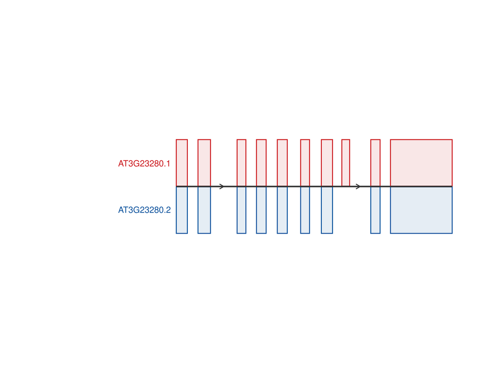

```r
library(ggtranscript)

g_annotation <- gtf %>% filter(gene_id == "AT3G23280")
g_annotation_exons <- g_annotation %>% dplyr::filter(type == "exon")
g_annotation_cds <- g_annotation %>% dplyr::filter(type == "CDS")
tx_ids <- unique(g_annotation_exons$transcript_id)

g_annotation_exons_1 <- g_annotation_exons %>% filter(transcript_id == tx_ids[1])
g_annotation_exons_2 <- g_annotation_exons %>% filter(transcript_id == tx_ids[2])
g_annotation_cds_1 <- g_annotation_cds %>% filter(transcript_id == tx_ids[1])
g_annotation_cds_2 <- g_annotation_cds %>% filter(transcript_id == tx_ids[2])

tx_cols <- c("#CB181D","#08519C")

p_exon <-
  g_annotation_cds_1 %>%
  ggplot(aes(
    xstart = start,
    xend = end,
    y = "y"
  )) +
  geom_half_range(
    aes(fill = transcript_id, col = transcript_id),
    height = 0.125,
    range.orientation =  "top",
    alpha = 0.1,
    linewidth = 0.5,
    position = position_nudge(y = 0.001)
  ) +
  geom_half_range(
    aes(fill = transcript_id, col = transcript_id),
    data = g_annotation_cds_2,
    height = 0.125,
    alpha = 0.1,
    linewidth = 0.5,
    position = position_nudge(y = -0.001)
  ) +
  geom_intron(
    data = to_intron(g_annotation_exons_1, "transcript_id"),
    col = "grey20",
    arrow = grid::arrow(ends = "last", length = grid::unit(2, "mm")),
    linewidth = 0.5,
    arrow.min.intron.length = 150,
    strand = g_annotation_cds_1$strand[1]
  ) +
  scale_fill_manual(values = tx_cols, aesthetics = c("color","fill")) +
  theme_void() +
  theme(
    plot.margin = unit(c(-1.5, 1, -1.5, 1), "cm"),
    legend.position = "none"
  ) +
  annotate("segment", x = min(g_annotation_cds_2$start), xend = max(g_annotation_cds_2$end),
           y = "y", yend = "y", col = "grey20", linewidth = 0.8) +
  xlim(min(g_annotation_cds_2$start) - 1200,NA) +
  annotate("text", x = min(g_annotation_cds_2$start) - 50, y = 1 + 0.125/2, label = tx_ids[1],
           hjust = 1, size = 3.5, col = tx_cols[1]) +
  annotate("text", x = min(g_annotation_cds_2$start) - 50, y = 1 - 0.125/2, label = tx_ids[2],
           hjust = 1, size = 3.5, col = tx_cols[2]);p_exon
```

### OSE rule plots

When estimating the changepoint, `cpam` applies the one-standard error to mitigate overfitting by taking into account model selection uncertainty. To visualise the rule, we plot the pointwise score differences and their standard errors for all changepoints.

First we extract the score table which contains the pointwise cross-validation scores for each model (changepoint).

```r
score_table <-
  cpo$changepoints %>%
  filter(target_id == "AT3G23280.1") %>%
  pull(score_table) %>%
  .[[1]]

score_table
```

| 0 | 30 | 60 | 67.5 | 75 | 90 | 120 |
| --- | --- | --- | --- | --- | --- | --- |
| 7.598973 | 7.358850 | 7.365828 | 7.411156 | 7.336559 | 7.235857 | 7.068561 |
| 7.874681 | 7.695781 | 7.824807 | 7.973494 | 7.867765 | 7.715203 | 7.445554 |
| 8.645790 | 9.271161 | 10.605813 | 11.575871 | 11.235771 | 10.668706 | 9.457585 |
| 7.883495 | 7.512009 | 7.815168 | 8.068152 | 7.933827 | 7.728419 | 7.327784 |
| 7.189864 | 7.190140 | 7.164199 | 7.176458 | 7.112156 | 7.027985 | 6.890122 |
| 7.018465 | 7.104031 | 7.002913 | 6.957187 | 6.909974 | 6.854967 | 6.778184 |
| 8.019046 | 8.136871 | 7.572080 | 7.489923 | 7.450180 | 7.414091 | 7.407897 |
| 7.548288 | 7.617445 | 7.423204 | 7.207820 | 7.206759 | 7.237781 | 7.377743 |
| 7.207033 | 7.107907 | 8.240762 | 7.535199 | 7.674786 | 7.953033 | 8.647163 |
| 8.259332 | 7.963778 | 8.081605 | 8.862343 | 9.092100 | 9.528795 | 10.577838 |

[output cut: 11 more lines]

Next, we determine the minimum scoring model, and compute the pointwise score differences.

```r
m.min <- score_table %>% purrr::map_dbl(mean) %>% which.min() %>% names; m.min
```

```
## [1] "30"
```

```r
score_table_diff <- score_table - score_table[[m.min]]
score_table_diff
```

| 0 | 30 | 60 | 67.5 | 75 | 90 | 120 |
| --- | --- | --- | --- | --- | --- | --- |
| 0.2401229290 | 0 | 0.0069781178 | 0.05230641 | -0.02229073 | -0.12299299 | -0.29028862 |
| 0.1789003039 | 0 | 0.1290260218 | 0.27771343 | 0.17198387 | 0.01942178 | -0.25022755 |
| -0.6253710368 | 0 | 1.3346518756 | 2.30470979 | 1.96460974 | 1.39754509 | 0.18642363 |
| 0.3714850915 | 0 | 0.3031585238 | 0.55614226 | 0.42181740 | 0.21640903 | -0.18422540 |
| -0.0002758873 | 0 | -0.0259409404 | -0.01368179 | -0.07798464 | -0.16215476 | -0.30001856 |
| -0.0855656215 | 0 | -0.1011178692 | -0.14684429 | -0.19405756 | -0.24906396 | -0.32584685 |
| -0.1178249139 | 0 | -0.5647900977 | -0.64694718 | -0.68669077 | -0.72277919 | -0.72897314 |
| -0.0691564913 | 0 | -0.1942405849 | -0.40962481 | -0.41068595 | -0.37966395 | -0.23970167 |
| 0.0991261365 | 0 | 1.1328544832 | 0.42729192 | 0.56687910 | 0.84512591 | 1.53925585 |
| 0.2955537856 | 0 | 0.1178267703 | 0.89856495 | 1.12832206 | 1.56501665 | 2.61405921 |

[output cut: 11 more lines]

Finally, we compute and plot the mean score differences and their standard errors. The OSE-selected changepoint is latest changepoint whose score is within one standard error of the minimum score difference.

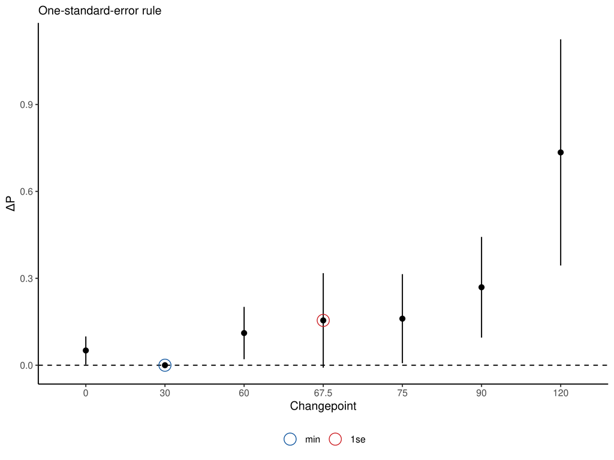

```r
  tibble(cp = names(score_table_diff) %>% {factor(.,.)},
       score_diff = score_table_diff %>% purrr::map_dbl(mean),
       se_diff = score_table_diff %>% purrr::map_dbl(~sd(.x)/sqrt(nrow(score_table_diff)))) %>%
  ggplot(aes(x = cp)) +
  geom_linerange(aes(ymin = score_diff - se_diff,
                     ymax = score_diff + se_diff)) +
  geom_hline(yintercept = 0, lty = "dashed") +
  geom_point(aes(y = score_diff, colour = "min"), shape = 1, size = 5,
             data = ~ filter(.x, score_diff == min(score_diff))) +
  geom_point(aes(y = score_diff, colour = "1se"), shape = 1, size = 5,
             data = ~ filter(.x, se_diff >= score_diff) %>%
               filter(as.numeric(cp) == max(as.numeric(cp)))) +
  geom_point(aes(y = score_diff), size = 2) +
  scale_colour_manual(values = c(`1se` = "#CB181D", min = "#08519C"),
                      breaks = c("min","1se")) +
  labs(col = NULL, y = expression(Delta*"P"), x = "Changepoint",
       subtitle = "One-standard-error rule") +
  theme_classic() +
  theme(legend.position = "bottom")
```

For the target AT3G23280.1, the OSE rule selects the changepoint at 67.5 mins, although we can see that the subsequent point at 75 mins is a close contender (compare the OSE plot above with the earlier plot of the data and fitted model). For comparison, we plot below the fitted model using the minimum scoring model instead of the OSE-selected model.

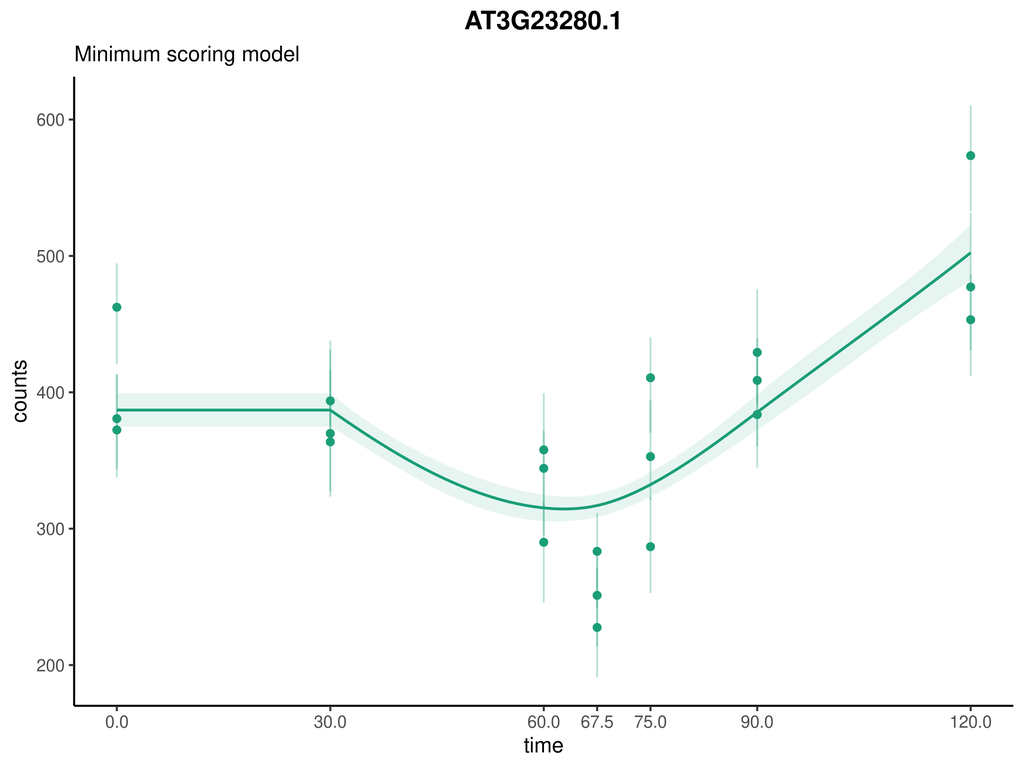

```r
plot_cpam(cpo, target_id = "AT3G23280.1", cp_type = "cp_min", bs = "tp") +
  labs(subtitle = "Minimum scoring model")
```

In general, the minimum scoring model captures a more complex trend than the OSE-selected model, although the OSE-selected model is likely to generalise better to new data. See the `cpam` manuscript for a simulation study comparing the two selection rules.

### Extract plot data for full customisation

If you require more customisation than the `plot_cpam` function allows, you can extract the model fits and plot their predictions manually. Here we show how to extract the model fits, model predictions, and observed data for a given target.

```r
# extract the model fit(s)
fit <- plot_cpam(cpo, target_id = "AT3G23280.1",return_fits_only = T)
# generate model prediction data
cpam:::predict_cpgam(fit, logged = F, length.out = 200, ci_prob = "se")
```

| time | td | counts | q_lo | q_hi |
| --- | --- | --- | --- | --- |
| 0.0000000 | 67.50000 | 341.4657 | 334.5968 | 348.3347 |
| 0.6030151 | 67.50000 | 341.4657 | 334.5968 | 348.3347 |
| 1.2060302 | 67.50000 | 341.4657 | 334.5968 | 348.3347 |
| 1.8090452 | 67.50000 | 341.4657 | 334.5968 | 348.3347 |
| 2.4120603 | 67.50000 | 341.4657 | 334.5968 | 348.3347 |
| 3.0150754 | 67.50000 | 341.4657 | 334.5968 | 348.3347 |
| 3.6180905 | 67.50000 | 341.4657 | 334.5968 | 348.3347 |
| 4.2211055 | 67.50000 | 341.4657 | 334.5968 | 348.3347 |
| 4.8241206 | 67.50000 | 341.4657 | 334.5968 | 348.3347 |
| 5.4271357 | 67.50000 | 341.4657 | 334.5968 | 348.3347 |

[output cut: 190 more lines]

The count data can be extract the `cpam` object

```r
cpo$data_long %>% filter(target_id == "AT3G23280.1")
```

| target_id | sample | counts_raw | counts | time | rep | gene_id | overdispersions | counts_scaled | q_lo | q_hi | norm_factor | disp |
| --- | --- | --- | --- | --- | --- | --- | --- | --- | --- | --- | --- | --- |
| AT3G23280.1 | pc_t0_r1 | 356.3607 | 74.91097 | 0.0 | 1 | AT3G23280 | 4.757123 | 74.91097 | 323.0581 | 395.6094 | 0.9569024 | 0.016707 |
| AT3G23280.1 | pc_t0_r2 | 451.8730 | 94.98871 | 0.0 | 2 | AT3G23280 | 4.757123 | 94.98871 | 408.1538 | 490.3966 | 1.1870000 | 0.016707 |
| AT3G23280.1 | pc_t0_r3 | 547.9774 | 115.19093 | 0.0 | 3 | AT3G23280 | 4.757123 | 115.19093 | 498.5461 | 586.2644 | 1.1851263 | 0.016707 |
| AT3G23280.1 | pc_t30_r1 | 402.6517 | 84.64184 | 30.0 | 1 | AT3G23280 | 4.757123 | 84.64184 | 383.5126 | 447.7186 | 1.0226532 | 0.016707 |
| AT3G23280.1 | pc_t30_r2 | 316.1296 | 66.45395 | 30.0 | 2 | AT3G23280 | 4.757123 | 66.45395 | 279.7852 | 368.6209 | 0.8547843 | 0.016707 |
| AT3G23280.1 | pc_t30_r3 | 288.5872 | 60.66423 | 30.0 | 3 | AT3G23280 | 4.757123 | 60.66423 | 256.7384 | 330.8092 | 0.7935683 | 0.016707 |
| AT3G23280.1 | pc_t60_r1 | 418.2214 | 87.91478 | 60.0 | 1 | AT3G23280 | 4.757123 | 87.91478 | 369.1612 | 466.8070 | 1.1688885 | 0.016707 |
| AT3G23280.1 | pc_t60_r2 | 366.9340 | 77.13359 | 60.0 | 2 | AT3G23280 | 4.757123 | 77.13359 | 314.6023 | 396.3350 | 1.0658857 | 0.016707 |
| AT3G23280.1 | pc_t60_r3 | 272.9598 | 57.37918 | 60.0 | 3 | AT3G23280 | 4.757123 | 57.37918 | 231.2820 | 300.4728 | 0.9411191 | 0.016707 |
| AT3G23280.1 | pc_t67.5_r1 | 214.7639 | 45.14574 | 67.5 | 1 | AT3G23280 | 4.757123 | 45.14574 | 182.6039 | 241.2184 | 0.8552797 | 0.016707 |

[output cut: 11 more lines]

We demonstrate use of these data for manual plotting in the [human embryo case study](https://raw.githack.com/l-a-yates/cpam_manuscript/main/R/torre.html).

Crisp, Peter A., Diep R. Ganguly, Aaron B. Smith, Kevin D. Murray, Gonzalo M. Estavillo, Iain Searle, Ethan Ford, et al. 2017. “Rapid Recovery Gene Downregulation During Excess-Light Stress and Recovery in Arabidopsis.” *The Plant Cell* 29 (8): 1836–63. https://doi.org/10.1105/tpc.16.00828.

Yates, Luke A., Jazmine L. Humphreys, Michael A. Charleston, and Steven M. Smith. 2024. “Shape-Constrained, Changepoint Additive Models for Time Series Omics Data with *Cpam*.” *BioRxiv*, December. https://doi.org/10.1101/2024.12.22.630003.